# Exercise Week 6 - Differential expression with the limma package

The purpose of this exercise is to simulate some “microarray” data and explore how well different statistical tests separate truly differential expression (in a small sample situation). This will introduce you to: i) simulation; ii) metrics to assess statistical performance; iii) some variations of the t-test.

Specifically, we will create a synthetic dataset with replicates from 2 experimental conditions and put in differential expression for some features. The goal is to see how well different statistical summaries can distinguish between those “truly” differential and those not differential.

```r
library("limma")
```

Next, we set some parameters for the simulation. You will modify these to explore a few situations.

```r
nGenes <- 10000                   # number of "features"
nSamples <- 6                     # number of samples (split equal in 2 groups)
pDiff <- .1                       # percent of genes "differential
grp <- rep(0:1,each=nSamples/2)   # dummy variable for exp. group
trueFC <- 2                       # log-fold-change of truly DE

d0 <- 1
s0 <- 0.8
sd <- s0*sqrt(d0/rchisq(nGenes,df=d0))  # dist'n of s.d.
```

Note: there are some details regarding the scaled inverse chi-square distribution that you may want to explore.  
For example, see the [wiki description](http://en.wikipedia.org/wiki/Scaled_inverse_chi-square_distribution).

#### Question 1. Look at the distribution of “true” s.d. (each gene has a different s.d.). You will change this distribution later to see effect on differential detection performance.

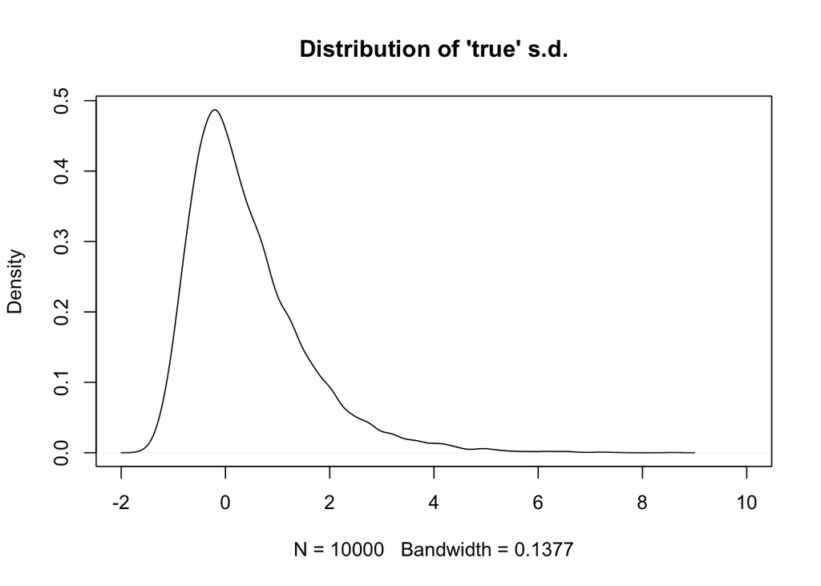

```r
plot(density(log(sd)),xlim=c(-2,10),main = "Distribution of 'true' s.d.")
```

Next, we can generate a table of (null) data:

```r
y <- matrix(rnorm(nGenes*nSamples,sd=sd),
            nr=nGenes,nc=nSamples)
```

And, we can add in “differential expression”, randomly chosen to be in the positive or negative direction, to a set of indices chosen:

```r
indD <- 1:floor(pDiff*nGenes)
diff <- sample(c(-1,1),max(indD),replace=TRUE)*trueFC
y[indD,grp==1] <- y[indD,grp==1] + diff
```

#### Question 2. To make sure you understand the simulation, look at some of the rows in the table. For example, plot the data (e.g., a barplot) for one of the features that is differential and one that is non-differential.

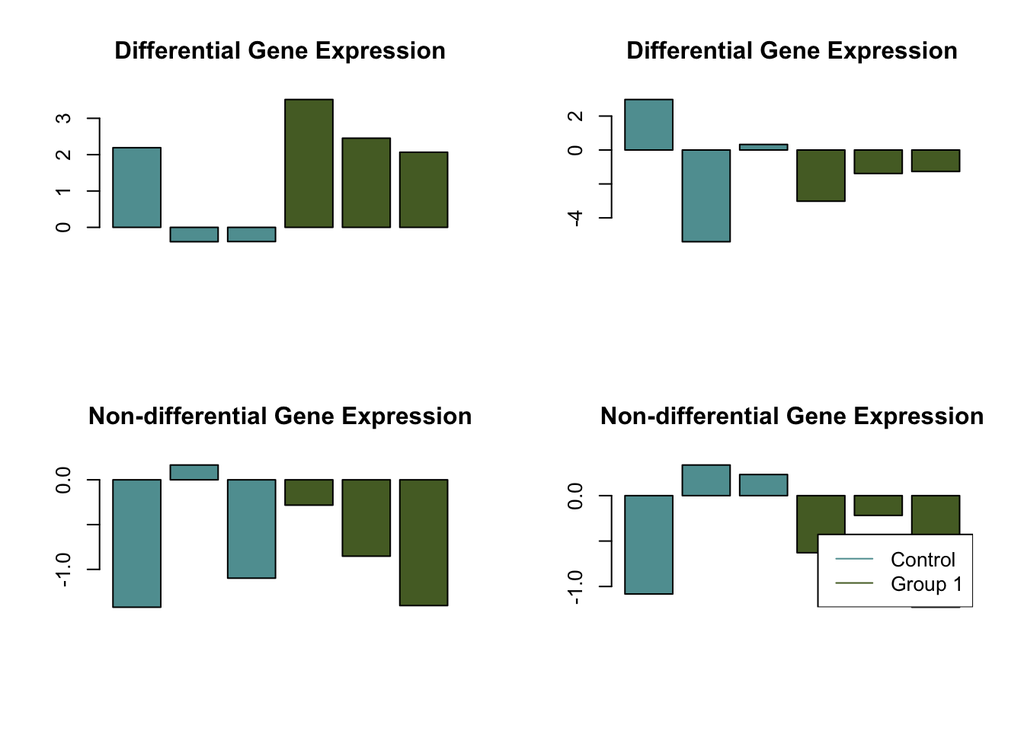

```r
par(mfrow = c(2,2))
cols = c("cadetblue","cadetblue","cadetblue","darkolivegreen","darkolivegreen","darkolivegreen")
barplot(y[250,], main = "Differential Gene Expression", col = cols)
barplot(y[750,], main = "Differential Gene Expression", col = cols)
barplot(y[3000,], main = "Non-differential Gene Expression", col = cols)
barplot(y[8000,], main = "Non-differential Gene Expression", col = cols)
legend("bottomright", c("Control", "Group 1"), col = c("cadetblue","darkolivegreen"), lty =1)
```

```r
par(mfrow = c(1,1))
```

Next, we create a design matrix to feed into limma:

```r
design <- model.matrix(~grp)
```

#### Question 3. What is the interpretation of the two columns of this design matrix?

Below is a standard limma pipeline. We will unravel many details of these steps in the coming weeks.

```r
fit <- lmFit(y,design)
fit <- eBayes(fit)
```

*A design matrix specifies the experimental condition of each sample by using dummy variables.*

#### Question 4. For each row in the simulated table, calculate the classical 2-sample t-test (perhaps store the result in a vector named ‘classicalt’; see below). See ?t.test for more details about the built-in R function to do this calculation and convince yourself which arguments to use to match the t-test described in class.

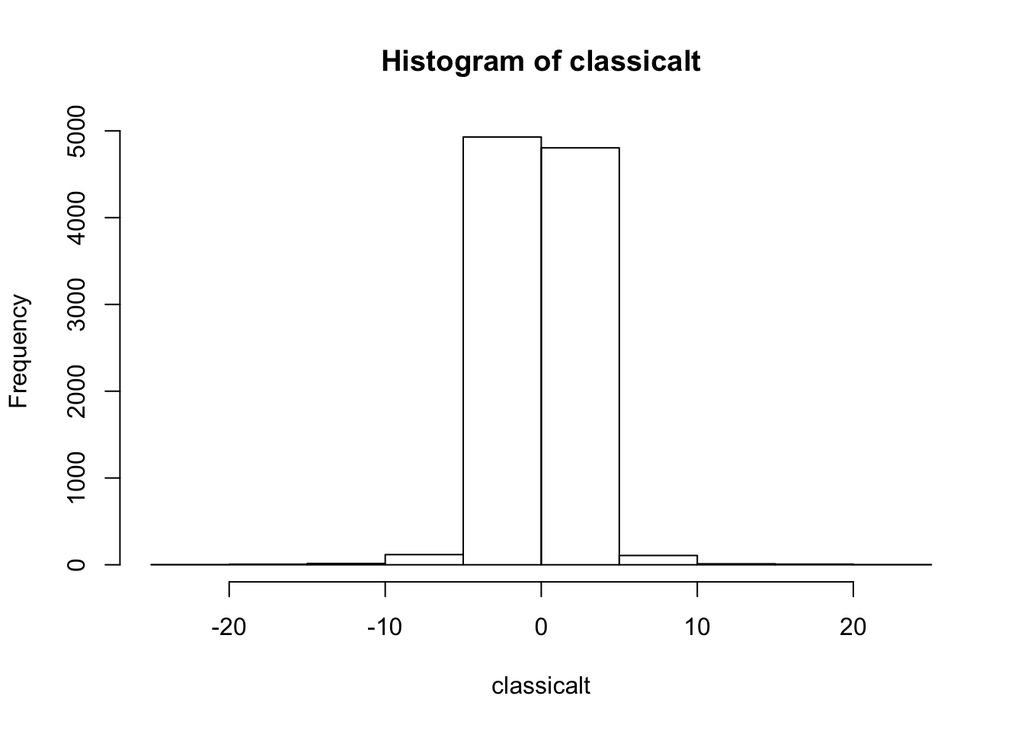

```r
classicalt <- rep(NA,length(y[,1]))
classicalp <- rep(NA,length(y[,1]))
for (i in 1:length(y[,1])){
  classicalt[i]<-t.test(y[i,1:3],y[i,4:6],var.equal= TRUE)$statistic
  classicalp[i]<-t.test(y[i,1:3],y[i,4:6],var.equal= TRUE)$p.value
}
hist(classicalt)
```

```r
length(which(classicalp< 0.01))
```

```
## [1] 325
```

Below, a vector of colours is made to signify the true differential “status”, which will be used in exploratory plots:

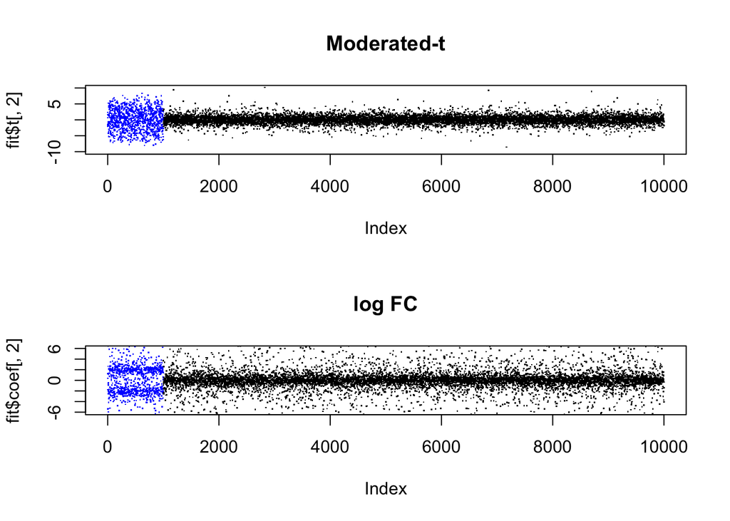

```r
cols <- rep("black",nrow(y))
cols[indD] <- "blue"

par(mfrow=c(2,1))
plot( fit$t[,2], col=cols, ylim=c(-10,10), pch=".", main="Moderated-t" )
plot( fit$coef[,2], col=cols, ylim=c(-6,6), pch=".", main="log FC" )
```

#### Question 5. Add an exploratory visualization to your plots above, perhaps with a command similar to below. From this visualization, summarize any differences you see between the three statistical summaries of a change between experimental groups.

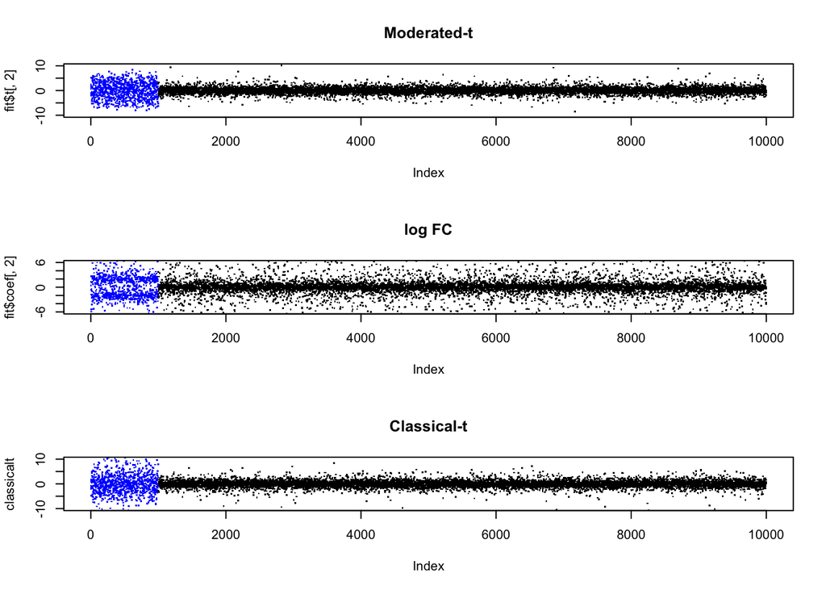

```r
par(mfrow=c(3,1))
plot( fit$t[,2], col=cols, ylim=c(-10,10), pch=".", main="Moderated-t" )
plot( fit$coef[,2], col=cols, ylim=c(-6,6), pch=".", main="log FC" )
plot( classicalt, col=cols, ylim=c(-10,10), pch=".", main="Classical-t" )
```

#### Question 6. Pick a reasonable metric to compare the methods: ROC curve, false discovery plot, power versus achieved FDR. Using this metric/curve, compare the classical t-test (classicalt), the moderated t-test (fit$t) and the log-fold-change or mean difference (fit$coef). Either manually calculate and plot it or use a nice package for it (e.g., https://rocr.bioinf.mpi-sb.mpg.de/ or https://github.com/markrobinsonuzh/benchmarkR) What method(s) perform well?

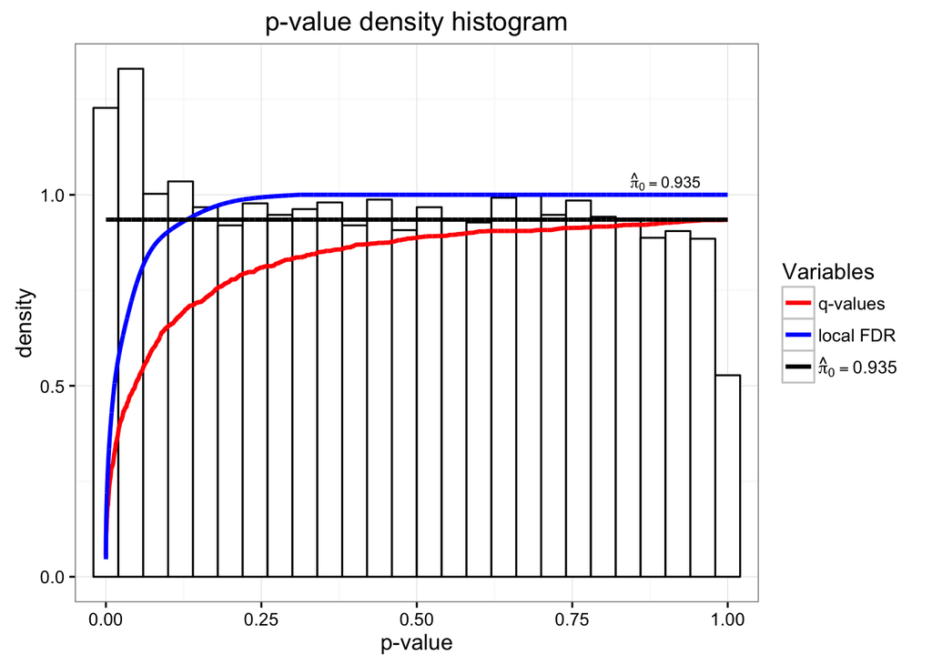

```r
library("devtools")
library("qvalue")

q_classicalt <- qvalue(p = classicalp)
q_moderatet <- qvalue(p = fit[,2]$p.value)
par(mfrow=c(1,2))
hist(q_classicalt,main="p-values from Classical t")
```

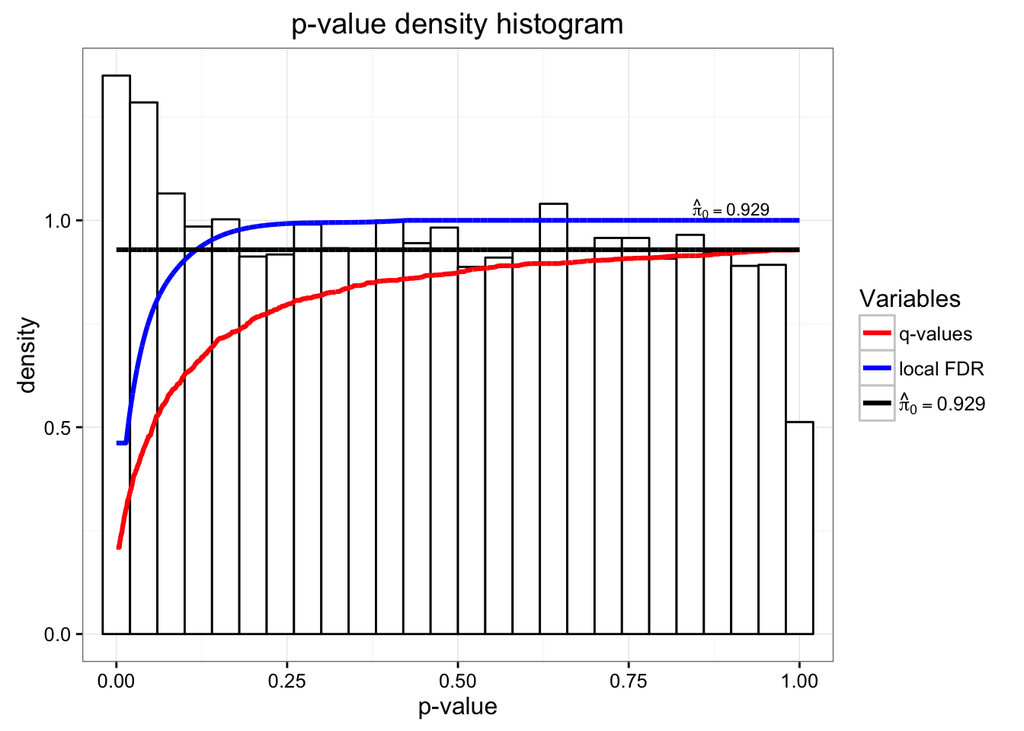

```r
hist(q_moderatet,main="p-values from Moderate t")
```

#### Question 7. Explore the performance of these test statistics for a few scenarios. For example, change the sample size, the number of genes DE, magnitude of the difference, level of variability. What influence do these parameters have on the relative performance?

#### Note: Submit both an Rmarkdown/markdown file as well as a compiled HTML file to your private github repository.